# GLENDA data cleaning description

# Load and setup

- Data sources
  - [GLENDA](https://cdxapps.epa.gov/cdx-glenda/action/querytool/querySystem)
  - [QA codes](https://cdxapps.epa.gov/cdx-glenda/action/linkdownloads/ExcelDownloads?downloadFile=&uploadFileId=964) taken from 2019 prepackaged data, from the “Qualifiers” sheet. Note: Didn’t use “QC codes” sheet because couldn’t find where this would map to the dataset
  - Didn’t utilize Depth codes from prepackaged workbook either

There were a couple initial filter choices when we initially loaded the data for exploration.

- Pivot the data into a long format
- Enforce stict data types for each column
- SAMPLE TYPES were either “Individual” or “INSITU_MEAS”
- QC TYPEs were “routine field sample”
- Dropped observations where both VALUE and RESULT_REMARK are missing
  - This is before enforcing VALUE is a number, so we wouldn’t induce a missing value
  - We will deal with the induced NA’s on the basis of the RESULT_REMARK
- Inferred inclusion risks for each RESULT_REMARK (see later in report)
- force Values to be numeric. Note: Some of them had words in them if they were questionable

| YEAR | MONTH | SEASON | LAKE | CRUISE_ID | VISIT_ID | STATION_ID | STN_DEPTH_M | LATITUDE | LONGITUDE | SAMPLING_DATE | TIME_ZONE | SAMPLE_DEPTH_M | DEPTH_CODE | MEDIUM | SAMPLE_TYPE | QC_TYPE | SAMPLE_ID | ANL_CODE2 | ANL_CODE | ANALYTE | VALUE | UNITS | FRACTION | METHOD | RESULT_REMARK | REMARK_RISK | VALUE2 | UNITS2 |
| --- | --- | --- | --- | --- | --- | --- | --- | --- | --- | --- | --- | --- | --- | --- | --- | --- | --- | --- | --- | --- | --- | --- | --- | --- | --- | --- | --- | --- |
| 2000 | April | Spring | Michigan | SP2000 | M011A00 | MI11 | 131.8 | 42.38078 | -86.99823 | 2000-04-09 | EST | 2 | Surface | surface water | Individual | routine field sample | 00GA25S01 | Alk-tot as CaCO3_Total/Bulk | Alk-tot as CaCO3 | Alkalinity, Total as CaCO3 | 109.000 | mg/l | Total/Bulk | LG500 | NA | NA | 109.000 | mg/l |
| 2000 | April | Spring | Michigan | SP2000 | M011A00 | MI11 | 131.8 | 42.38078 | -86.99823 | 2000-04-09 | EST | 2 | Surface | surface water | Individual | routine field sample | 00GA25S01 | Chlor-a_Residue | Chlor-a | Chlorophyll-a | 0.030 | ug/l | Residue | LG405 | Field Lab Anomaly | HIGH | 0.030 | ug/l |
| 2000 | April | Spring | Michigan | SP2000 | M011A00 | MI11 | 131.8 | 42.38078 | -86.99823 | 2000-04-09 | EST | 2 | Surface | surface water | Individual | routine field sample | 00GA25S01 | Cl-_Total/Bulk | Cl- | Chloride | 10.810 | mg/l | Total/Bulk | LG205 | NA | NA | 10.810 | mg/l |
| 2000 | April | Spring | Michigan | SP2000 | M011A00 | MI11 | 131.8 | 42.38078 | -86.99823 | 2000-04-09 | EST | 2 | Surface | surface water | Individual | routine field sample | 00GA25S01 | Cond_Total/Bulk | Cond | Conductivity | 293.000 | umho/cm | Total/Bulk | LG500 | NA | NA | 293.000 | umho/cm |
| 2000 | April | Spring | Michigan | SP2000 | M011A00 | MI11 | 131.8 | 42.38078 | -86.99823 | 2000-04-09 | EST | 2 | Surface | surface water | Individual | routine field sample | 00GA25S01 | NO2+NO3_Total/Bulk | NO2+NO3 | Nitrogen, Total Oxidized | 0.329 | mg/l | Total/Bulk | LG203 | NA | NA | 0.329 | mg/l |
| 2000 | April | Spring | Michigan | SP2000 | M011A00 | MI11 | 131.8 | 42.38078 | -86.99823 | 2000-04-09 | EST | 2 | Surface | surface water | Individual | routine field sample | 00GA25S01 | P-tot_Filtrate | P-tot | Phosphorus, Total as P | 2.359 | ug/l | Filtrate | LG204 | NA | NA | 2.359 | ug/l |

# QC investigations

## Fractions

- Some fractions are reported missing
- Here are the suggested fractions, some are still unknown (Note: Adding unique Method didn’t yield new matches, that weren’t themselves missing)
- So far, this was purely based about solubility of the analytes

Table 2: Giving unreported fractions fraction labels

Unknown fractions and their suggested labels

Tablation of unique NA or Not applicable fractions and their suggested labels

| ANALYTE | FRACTION | suggestedFraction |
| --- | --- | --- |
| Alkalinity, Total as CaCO3 | Not applicable | Total/Bulk |
| Alkalinity, Total as CaCO3 | Total/Bulk | Total/Bulk |
| Chlorophyll-a | Residue | NA |
| Chlorophyll-a | Total/Bulk | NA |
| Chlorophyll-a | NA |  |
| Conductivity | Not applicable | Total/Bulk |
| Conductivity | Total/Bulk | Total/Bulk |
| Secchi Disc Transparency | Not applicable | Total/Bulk |
| Secchi Disc Transparency | NA | Total/Bulk |
| Temperature | Not applicable | Total/Bulk |
| Temperature | Total/Bulk | Total/Bulk |
| Turbidity | Not applicable | Total/Bulk |
| Turbidity | Total/Bulk | Total/Bulk |
| pH | Not applicable | Total/Bulk |
| pH | Total/Bulk | Total/Bulk |

## NAs, Remarks, and problematic values

Table 3: Listing all of the remarks and whether the values were reported or just NA

Missing/estimated/Measured values

Types of reported values and their treatment

| VALUE | treatment | RESULT_REMARK |
| --- | --- | --- |
| 0 | Impute | Method Detection Limit, less than |
| 0 | Remove | Quality Control incomplete |
| 0 | Remove | Performance Check, failed |
| 0 | Remove | Outlier, single station |
| 0 | Remove | Field Duplicate, failed |
| < | Impute | Reporting Limit, less than |
| < | Impute | Estimated Value, outside limit of precision |
| < | Impute | Detection Limit, less than |
| < | Remove | Lab Calibration Verification Solution, failed |
| < | Remove | Performance Check, failed |
| < | Remove | Field Duplicate, failed |
| < | Remove | Field Reagent Blank, failed |
| < | Remove | Lab Duplicate, failed |
| < | Remove | Exceeded Holding Time |
| Negative | Impute | Method Detection Limit, less than |
| Negative | Remove | Exceeded Holding Time |
| Negative | Remove | Lab Reagent Blank, failed |
| Negative | Remove | Lab Duplicate, failed |
| Not Reported | Impute | Detection Limit, less than |
| Not Reported | Remove | Lab Duplicate, failed |
| Not Reported | Remove | Invalid |
| Not Reported | Remove | No Result Reported, other |
| Not Reported | Remove | No Result Reported, lab accident |
| Not Reported | Remove | Field Reagent Blank, failed |
| Not Reported | Remove | No Result Reported, analysis canceled |
| Not Reported | Remove | Performance Check, failed |
| Not Reported | Remove | No Result Reported, lab accident |
| Not Reported | Remove | Performance Check, failed |
| Not Reported | Remove | null |
| Not Reported | Remove | null |
| Not Reported | Remove | Lab Reagent Blank, failed |
| Not Reported | Remove | Quality Control incomplete |
| Reported | Impute | Method Detection Limit, less than |
| Reported | Impute | Estimated Value, outside limit of precision |
| Reported | Impute | Reporting Limit, less than |
| Reported | Impute | Between Instrument Detection and Quantification Limits |
| Reported | Keep | Correction Factor, lab |
| Reported | Keep | CLP Flag, Estimate |
| Reported | Keep | Estimated Value, serial dilution difference |
| Reported | Remove | Quality Control incomplete |
| Reported | Remove | Exceeded Holding Time |
| Reported | Remove | Field Lab Anomaly |
| Reported | Remove | Suspected Contamination, field |
| Reported | Remove | Field Reagent Blank, failed |
| Reported | Remove | Lab Duplicate, failed |
| Reported | Remove | Field Duplicate, failed |
| Reported | Remove | Quality Control incomplete |
| Reported | Remove | Field Reagent Blank, failed |
| Reported | Remove | Performance Check, failed |
| Reported | Remove | Invalid |
| Reported | Remove | Suspected Contamination, unknown |
| Reported | Remove | Suspected Contamination, lab analysis |
| Reported | Remove | Lab Reagent Blank, failed |
| Reported | Remove | Performance Check, failed |
| Reported | Remove | Composite Inconsistent With Sample Results |
| Reported | Remove | Lab Calibration Verification Solution, failed |
| Reported | Remove | Likely Biased High |
| Reported | Remove | Likely Biased Low |
| Reported | Remove | Matrix Spike, failed |
| Reported | Remove | null |
| Reported | Remove | null |
| Reported | Remove | Lab Procedural Blank, failed |
| Reported | Remove | Lab Spike Blank, failed |
| Reported | Remove | Field Duplicate, failed |
| Reported | Remove | Likely Biased Low |
| Reported | Remove | Known Contamination, field |
| Reported | Remove | Blank Sample, failed |
| Reported | Remove | Outlier, accross stations |
| Reported | Remove | Outlier, single station |
| Reported | Remove | Exceeded Holding Time |
| Reported | Remove | Lab Reagent Blank, failed |

## Units

- For mismatched units:
  - For each Unique analyte, Fraction, and whether below 20 or not
- Saw if distributions differ
- Assume internally consistent
- Test log of distance between all pairwise combinations
- Identified mismatched units by testing if their means are significantly different
- labeled in the UNIT_DETERMINATION column

[figure not shown]

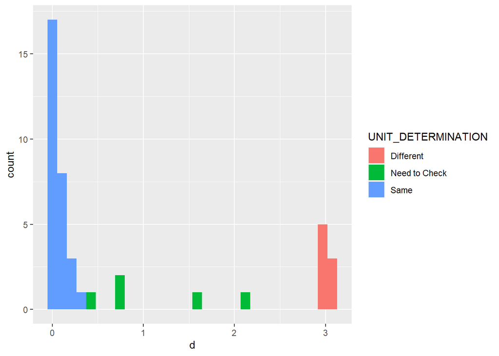

## LAT/LON precision

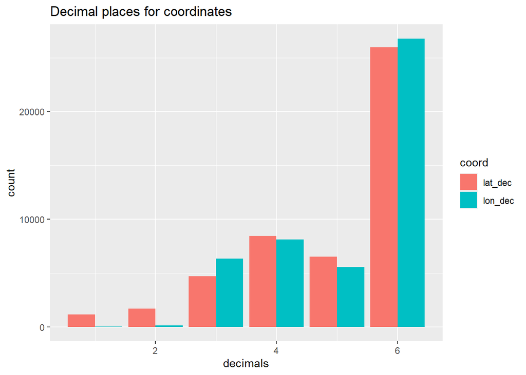

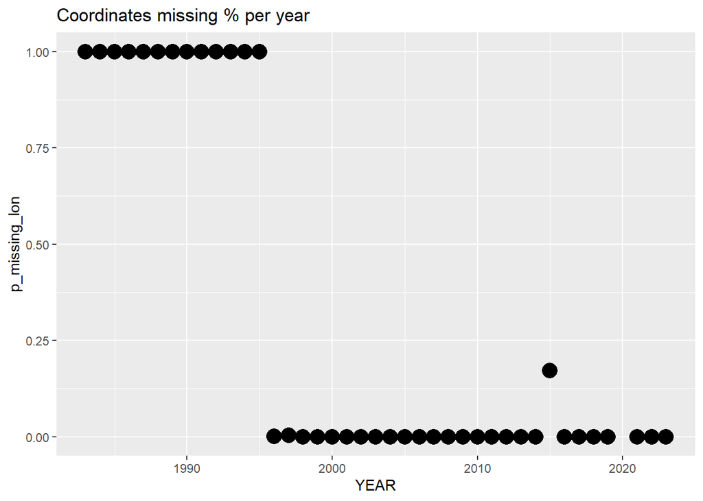

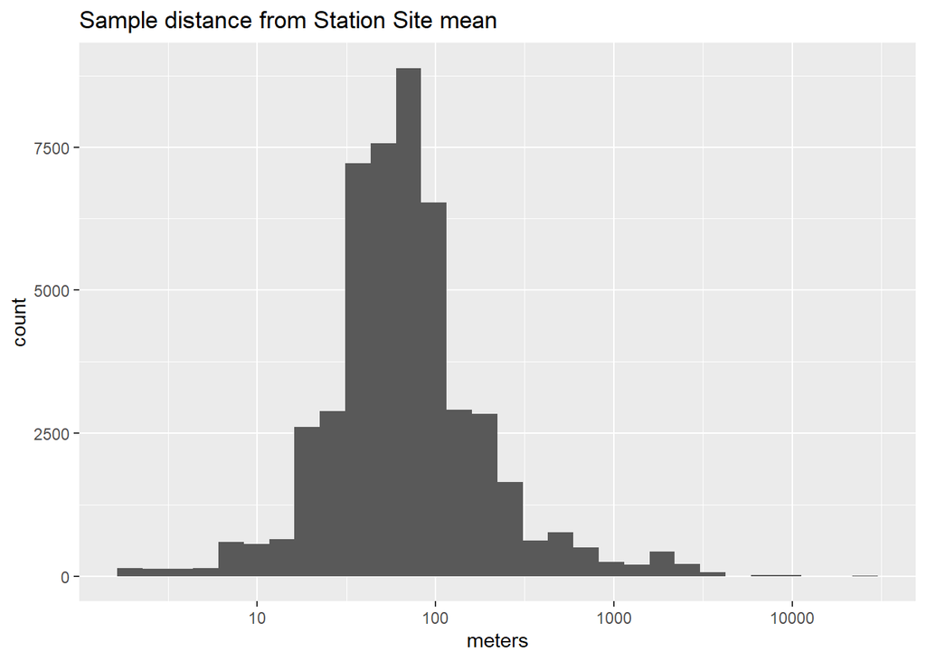

## Analyte names

- Named by hand after looking at the following table

A list of all unique Medium, Analyte, Fraction combinations to aid in determining a unified naming system. Additionally, we’ve included columns for different attempts at creating a naming system

| MEDIUM | ANALYTE | ANL_CODE | FRACTION | Years | METHOD | UNITS | Ryan's Names | Kelsey's names | NAME_COMMENT |
| --- | --- | --- | --- | --- | --- | --- | --- | --- | --- |
| air: ambient | Secchi Disc Transparency | Secchi | NA | 1999-1999 | LG402 | m | NA | NA | NA |
| air: ambient | Temperature | Temp | Not applicable | 2007-2008 | LG300 | C | NA | NA | NA |
| sediment | Carbon, Organic | C-org | Total/Bulk | 2002-2018 | LG601 | %, mg/g | Sed-C-ord | TOC | NA |
| sediment | Moisture content | Moist | Total/Bulk | 2015-2018 | LG604 | % | Sed-Moist | Sed_Moist | NA |
| sediment | Nitrogen, Total, Sediment | N-Sed | Total/Bulk | 2002-2018 | LG602 | mg/g | Sed-N-Sed | Sed_TN | NA |
| sediment | Phosphorus, Total as P, Sediment | P-Sed | Total/Bulk | 2002-2018 | LG600 | mg/g | Sed-P-Sed | Sed_TP | NA |
| surface water | Alkalinity, Total as CaCO3 | Alk-tot as CaCO3 | Not applicable | 2000-2000 | LG500 | mg/l | NA | NA | NA |
| surface water | Alkalinity, Total as CaCO3 | Alk-tot as CaCO3 | Total/Bulk | 1983-2023 | LG500, ANL_MTHD, NA | mg/l, none | CaCO3 | CaCO3 | NA |
| surface water | Ammonia-Nitrogen | NH3-N | Filtrate | 1985-1996 | ANL_MTHD, LG200 | ug/l, mg/l | F-NH3-N | NH3 | Kelsey: Isn't ammonia always measured as dissolved? |
| surface water | Ammonia-Nitrogen | NH3-N | Total/Bulk | 1983-1984 | ANL_MTHD | ug/l | T-NH3-N | NH3 | Kelsey: Isn't ammonia always measured as dissolved? |
| surface water | Ammonium-Nitrogen | NH4-N | Filtrate | 1994-1995 | NA | mg/l | F-NH4-N | NH4 | NA |
| surface water | Arsenic | As | Total/Bulk | 2016-2019 | LG213 | ug/l | T-As | Tot_As | NA |
| surface water | Calcium | Ca | Filtrate | 2021-2021 | E200.8 | ug/l | F-Ca | Diss_Ca | Kelsey: I'm suspicious the filtrate vs. total difference isn't real. Would be helpful to look at which years had these fractions, whether different methods were used in different years, etc. |
| surface water | Calcium | Ca | Total/Bulk | 2004-2019 | LG213 | mg/l | T-Ca | Tot_Ca | Kelsey: I'm suspicious the filtrate vs. total difference isn't real. Would be helpful to look at which years had these fractions, whether different methods were used in different years, etc. |
| surface water | Carbon, Organic | C-org | Filtrate | 1996-1997 | ANL_MTHD | mg/l | F-C-org | DOC | NA |
| surface water | Carbon, Organic | C-org | Residue | 1996-2019 | LG207, ANL_MTHD | mg/l, ug/l | P-C-org | POC | NA |
| surface water | Chloride | Cl- | Filtrate | 1983-2019 | LG205, ANL_MTHD, NA | mg/l | F-Cl- | Diss_Cl | Kelsey: I'm suspicious the filtrate vs. total difference isn't real. Would be helpful to look at which years had these fractions, whether different methods were used in different years, etc. |
| surface water | Chloride | Cl- | Total/Bulk | 1997-2021 | LG205, E300.0 | mg/l | T-Cl- | Tot_Cl | Kelsey: I'm suspicious the filtrate vs. total difference isn't real. Would be helpful to look at which years had these fractions, whether different methods were used in different years, etc. |
| surface water | Chlorophyll-a | Chlor-a | Residue | 1983-2022 | LG405, ANL_MTHD | ug/l | P-Chlor-a | Chlor_a | Kelsey: I would think these chl-a measurements are all the same? |
| surface water | Chlorophyll-a | Chlor-a | Total/Bulk | 1997-1997 | LG405 | ug/l | T-Chlor-a | Chlor_a | Ryan: I've not really heard of unfiltered chlorophyll but it could be real. |
| surface water | Chlorophyll-a | Chlor-a | NA | 2013-2018 | LG405 | ug/l | NA | NA | NA |
| surface water | Conductivity | Cond | Not applicable | 2000-2000 | LG500 | umho/cm | NA | NA | NA |
| surface water | Conductivity | Cond | Total/Bulk | 1983-2023 | LG500, ANL_MTHD, NA | umho/cm, none | Cond | Cond | NA |
| surface water | Hardness, Total as CaCO3 | Hard-tot as CaCO3 | Total/Bulk | 1995-2019 | LG500, LG502, NA | mg/l, none | NA | NA | Ryan: "Total Hardness" is typically definable as CaCO3 + MgCO3 rather than just CaCO3. You might check whether there's metholdological differences. If there's not, it could be merged with alkalinity. … |
| surface water | Magnesium | Mg | Filtrate | 2021-2021 | E200.8 | ug/l | F-Mg | Diss_Mg | Kelsey: I'm suspicious the filtrate vs. total difference isn't real. Would be helpful to look at which years had these fractions, whether different methods were used in different years, etc. |
| surface water | Magnesium | Mg | Total/Bulk | 2004-2019 | LG213 | mg/l | T-Mg | Tot_Mg | Kelsey: I'm suspicious the filtrate vs. total difference isn't real. Would be helpful to look at which years had these fractions, whether different methods were used in different years, etc. |
| surface water | Manganese | Mn | Filtrate | 2021-2021 | E200.8 | ug/l, none | F-Mn | Diss_Mn | Kelsey: I'm suspicious the filtrate vs. total difference isn't real. Would be helpful to look at which years had these fractions, whether different methods were used in different years, etc. |
| surface water | Manganese | Mn | Total/Bulk | 2016-2019 | LG213 | ug/l | T-Mn | Tot_Mn | Kelsey: I'm suspicious the filtrate vs. total difference isn't real. Would be helpful to look at which years had these fractions, whether different methods were used in different years, etc. |
| surface water | Molybdenum | Mo | Total/Bulk | 2016-2019 | LG213 | ug/l | T-Mo | Tot_Mo | NA |
| surface water | Nitrogen, Total | N-tot | Filtrate | 2016-2019 | LG214 | mg/l | F-N-tot | TDN | NA |
| surface water | Nitrogen, Total | N-tot | Total/Bulk | 2014-2015 | LG203, LG206 | mg/l | T-N-tot | TN | NA |
| surface water | Nitrogen, Total Oxidized | NO2+NO3 | Filtrate | 1983-2019 | LG203, LG205, ANL_MTHD, NA | mg/l | F-NOx | NOx | Kelsey: Isn't nitrate+nitrite always measured as dissolved? I think this should be checked |
| surface water | Nitrogen, Total Oxidized | NO2+NO3 | Total/Bulk | 1996-2021 | LG203, N07-0003 | mg/l | T-NOx | NOx | Kelsey: Isn't nitrate+nitrite always measured as dissolved? I think this should be checked |
| surface water | Nitrogen, Total, Particulate | N-Part | Residue | 2006-2019 | LG208 | mg/l | T-N-Part | TPN | NA |
| surface water | Oxygen, Dissolved | O2diss | Filtrate | 1983-1993 | ANL_MTHD | mg/l | O2diss | DO | Ryan: I think these are both the same and neither are filtered. That'd be strange. |
| surface water | Oxygen, Dissolved | O2diss | Total/Bulk | 2001-2012 | LG501, LG501A, LG501Y, NA | mg/l | O2diss | DO | Kelsey: DO is the common term for dissolved oxygen |
| surface water | Phosphorus, Base Extractable as P | P-NaOH as P | Residue | 2009-2019 | LG216 | ug/l | NA | NA | Ryan: I don't know this term. Some sort of reactive P that isn't comparable to Ortho-P? Need SOP to decide. |
| surface water | Phosphorus, Elemental | P | Filtrate | 1994-1995 | NA | ug/l | NA | TDP | Ryan: I think this is just dissolved total P but |
| surface water | Phosphorus, Orthophosphorus as P | P-ortho as P | Filtrate | 1983-2019 | LG215, ANL_MTHD, NA | ug/l, mg/l | F-P-ortho | SRP | Kelsey: Can we call this soluble reactive phosphorus (SRP)? This is the common term. Assuming 'orthophosphorus' the same thing as 'orthophosphate'? |
| surface water | Phosphorus, Total as P | P-tot | Filtrate | 1983-2019 | LG204, LG205, ANL_MTHD | ug/l, mg/l | F-P-tot | TDP | Kelsey: This is the common abbreviation |
| surface water | Phosphorus, Total as P | P-tot | Total/Bulk | 1983-2019 | LG204, LG205, ANL_MTHD, NA | ug/l, mg/l | T-P | TP | NA |
| surface water | Phosphorus, Total as P, Particulate | P-Part | Residue | 2006-2019 | LG209 | ug/l | P-P | TPP | Ryan: I giggled if I am being honest. |
| surface water | Potassium | K | Filtrate | 2021-2021 | E200.8 | ug/l | F-K | Diss_K | Kelsey: I'm suspicious the filtrate vs. total difference isn't real. Would be helpful to look at which years had these fractions, whether different methods were used in different years, etc. |
| surface water | Potassium | K | Total/Bulk | 2016-2019 | LG213 | mg/l | T-K | Tot_K | Kelsey: I'm suspicious the filtrate vs. total difference isn't real. Would be helpful to look at which years had these fractions, whether different methods were used in different years, etc. |
| surface water | Secchi Disc Transparency | Secchi | Not applicable | 1988-2022 | NA, LG402 | m, none | NA | NA | NA |
| surface water | Secchi Disc Transparency | Secchi | NA | 1998-2000 | NA, LG402 | m | NA | NA | NA |
| surface water | Selenium | Se | Total/Bulk | 2016-2019 | LG213 | ug/l | T-Se | Tot_Se | NA |
| surface water | Silica, Dissolved as Si | SiO4/SiO3 as Si | Filtrate | 1996-2019 | LG205 | mg/l | F-Si | Diss_Si | Ryan: Confirm methodologically these are in fact different that row 51. So do this sort of speciation the methods need ot be different I imagine. |
| surface water | Silica, Dissolved as Si | SiO4/SiO3 as Si | Total/Bulk | 1996-2000 | LG205 | mg/l | T-Si | Diss_Si? | Ryan: Confirm methodologically these are in fact different that row 51. So do this sort of speciation the methods need ot be different I imagine. Kelsey: The analyte name says dissolved but the fracti… |
| surface water | Silica, Total | SiO2 | Filtrate | 1983-1993 | ANL_MTHD | mg/l | NA | NA | Ryan: Confirm methodologically these are in fact different that row 49-50. So do this sort of speciation the methods need ot be different I imagine. If the method is the same, I think this would be F-… |
| surface water | Silicon, Elemental | Si | Filtrate | 1994-1995 | NA | mg/l | NA | NA | Ryan: Confirm methodologically these are in fact different that row 49-50. So do this sort of speciation the methods need ot be different I imagine. If the method is the same, I think this would be F-… |
| surface water | Sodium | Na | Filtrate | 2021-2021 | E200.8 | ug/l | F-Na | Diss_NA | Kelsey: I'm suspicious the filtrate vs. total difference isn't real. Would be helpful to look at which years had these fractions, whether different methods were used in different years, etc. |
| surface water | Sodium | Na | Total/Bulk | 2004-2019 | LG213 | mg/l | T-Na | Tot_NA | Kelsey: I'm suspicious the filtrate vs. total difference isn't real. Would be helpful to look at which years had these fractions, whether different methods were used in different years, etc. |
| surface water | Suspended solids, total | TSS | Residue | 2006-2019 | LG302 | mg/l | TSS | TSS | NA |
| surface water | Temperature | Temp | Not applicable | 1983-2023 | NA, LG200, ANL_MTHD, LG300 | C | NA | NA | NA |
| surface water | Temperature | Temp | Total/Bulk | 1986-1999 | ANL_MTHD, LG500 | C | Temp | Temp | NA |
| surface water | Turbidity | Turb | Not applicable | 2000-2000 | LG500 | NTU | NA | NA | NA |
| surface water | Turbidity | Turb | Total/Bulk | 1983-2023 | LG500, ANL_MTHD, NA | NTU, none, FTU | Turb | Turb | NA |
| surface water | pH | pH | Not applicable | 1986-2000 | LG500, ANL_MTHD | none | NA | NA | NA |
| surface water | pH | pH | Total/Bulk | 1983-2023 | LG500, ANL_MTHD, NA | none | pH | pH | NA |